# Laboratorio práctico 6 [GEO622]

MSc. José A. Lastra

2021-06-09

# Introducción

La función del siguiente documento es apoyar el desarrolo de las clases del curso GEO-622, vinculadas al uso y manipulación de geo-información empleando diferentes plataformas SIG.

Esta guía es un apoyo y no representa un reemplazo al contenido de las clases sincrónicas.

## 1.- Automatización con ModelBuilder

La herramienta **ModelBuilder** provee una interfaz visual para la creación de modelos de procesamiento y la automatización de flujos de trabajo. En la práctica, es una forma de programación visual (*aka R con cajas*) que permite llevar todos nuestros flujos normales de trabajo a un esquema ordenado y claro.

### 1.1.- Generando un nuevo modelo

Para este laboratorio abra **ArcGIS Pro** y cree un nuevo proyecto de mapa de nombre **modelBuilder_example**. Con el proyecto creado, conecte la carpeta **dataLab_6** que tiene promedios mensuales de Temperatura superficial del mar (SST) [MODIS Aqua, 4 km](https://oceancolor.gsfc.nasa.gov/l3/). desde enero de 2003 hasta diciembre de 2010.

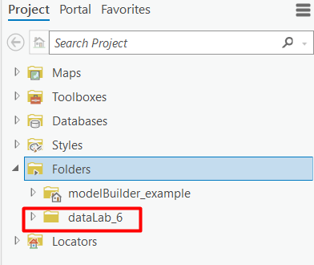

Vaya a la pestaña **Analysis** y cree un nuevo modelo que se abrirá como una nueva pestaña en su vista principal.

[figure not shown]

### 1.2.- Agregando datos y herramientas

En la cinta principal, podremos ver todas las herramientas disponibles para trabajar con nuestros modelos. Además podemos arrastrar directamente herramientas desde el toolbox.

[figure not shown]

Este nuevo modelo, se guarda automáticamente en el toolbox que se genera al crear nuestro proyecto inicial.

Para este ejercicio haremos un modelo simple que deberá realizar lo siguiente:

- Leer archivos desde la carpeta
- Crear un raster stack y guardarlo
- Calcular: media, mediana y desviación estándar

Con esa premisa, agregue la herramienta **Composite bands** que permite la creación de un raster stack. De click derecho sobre la herramienta y seleccione la opción **Create variable/From parameter/**.

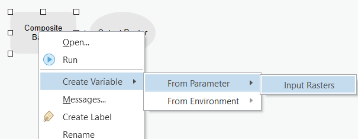

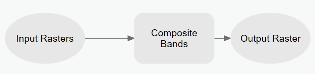

A continuación, agregue la herramienta **Cell Statistics** y conecte la salida de la herramienta **Composite bands** como **Input rasters or constant values**. Repita el proceso dos veces más para tener los tres estadísticos solicitados.

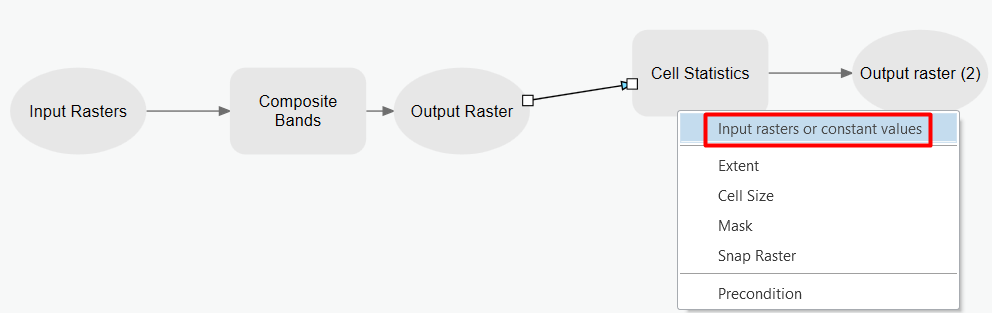

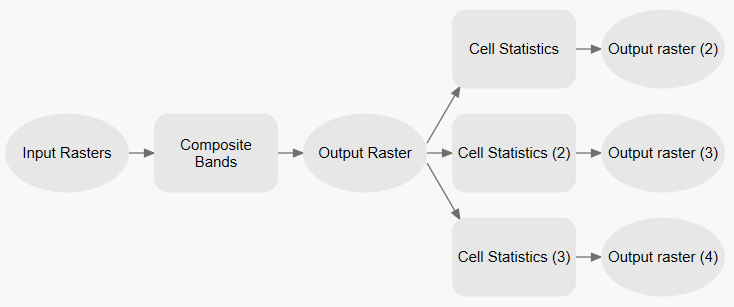

Ahora crearemos variables a partir de parámetros dentro de las herramientas de estadísticas de celdas. Para esto, haga click derecho sobre la herramienta y seleccione **Create variable/From parameter/Overlay statistic**. Repita el proceso dos veces más para completar.

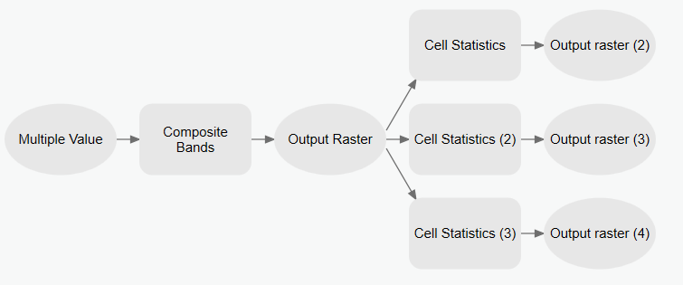

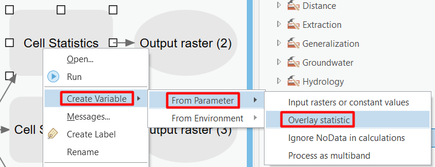

Agregue al final nuevamente **Composite bands** para agrupar las tres bandas en un solo resultado de salida.

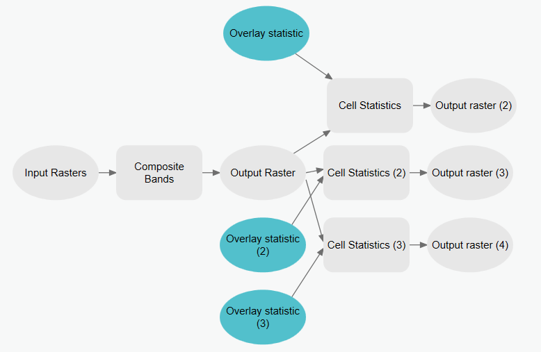

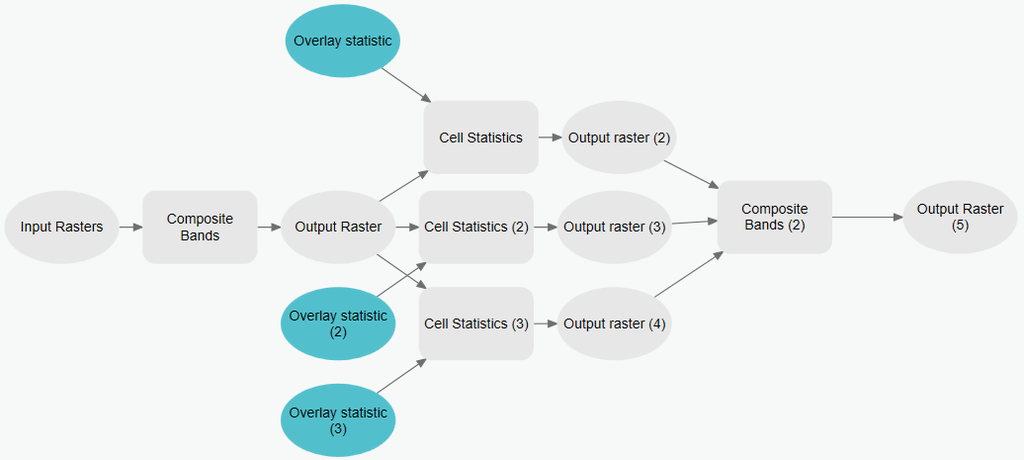

### 1.3.- Ejecución, precondiciones y parametrización

Con nuestro flujo estructuralmente creado, ahora procederemos a configurar entradas y testear el modelo completo. De doble click al input **Raster Layer** y agregue los archivos de la carpeta **monthly sst**. al agregar las bandas, el modelo se pondrá de colores indicando que está activo.

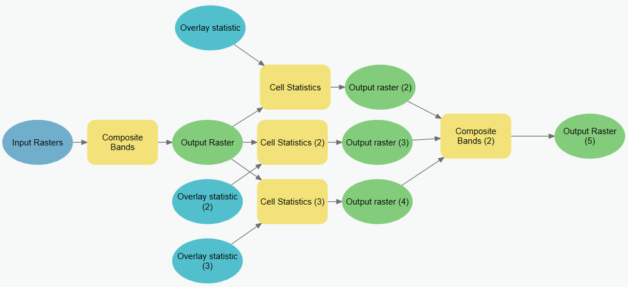

Antes de correr el modelo, configure las estadísticas en las entradas de Overlay Statistics de acuerdo a lo solicitado. Además, a la salida de cada Cell Statistic debe modificarle el nombre haciendo doble click.

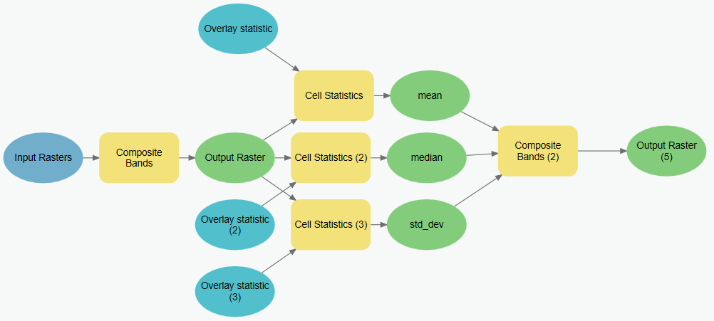

Finalmente haga click derecho sobre la salida final del modelo y marque la opción **Add to display** (puede cambiar también el nombre de esta salida).

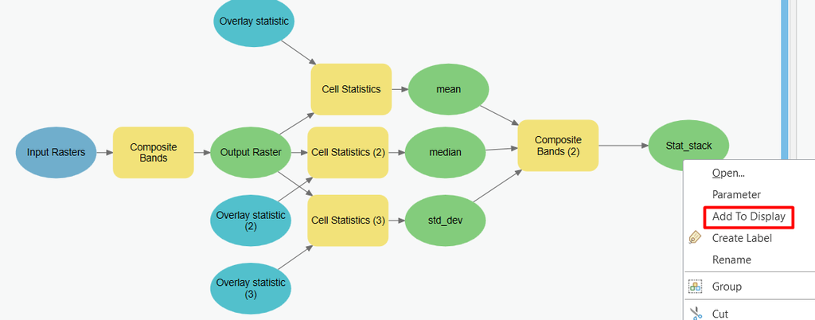

Ahora corra su modelo y revise el resultado obtenido.

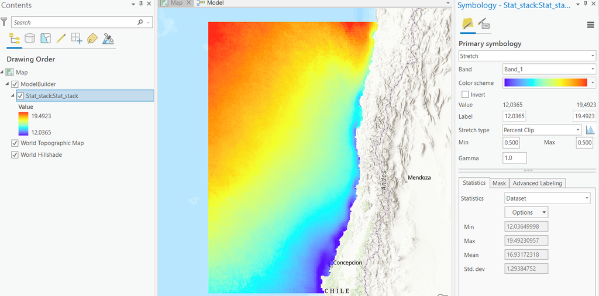

### 1.4.- Uso de iteraciones

Terminado nuestro modelo anterior, ahora haremos un ejercicio simple de iteraciones empleando las mismas imágenes del punto anterior. Los iteradores son herramientas que permiten realizar cualquier análisis de forma recursiva o reiterativa, ya sea para tablas, entidades, rasters, etc.

Cree un nuevo modelo (**Analysis/ModelBuilder**) y vaya al menú **Insert/Iterators**, ahí seleccione la opción **Iterate Rasters** y agréguela al modelo.

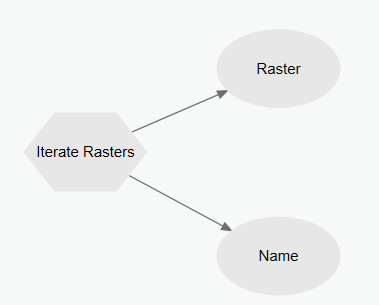

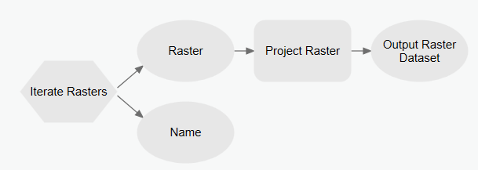

Ahora configuraremos las entradas a nuestro iterador, haciendo doble click sobre el mismo y seleccionaremos el formato de nuestros datos y la carpeta donde se encuentran.

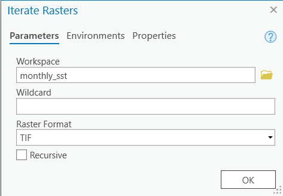

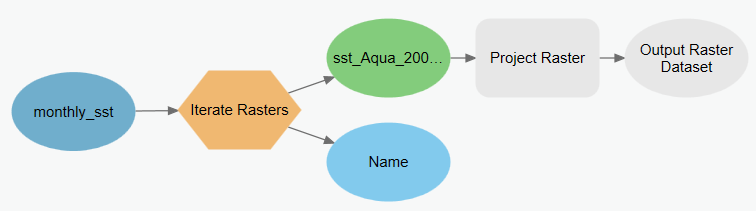

Ahora configuraremos los parámetros de nuestra herramienta de proyección; para el nombre de salida considere el siguiente argumento **%Name%** que mantendrá los nombres de salida como los nombres originales de los archivos. Las imágenes las guardaremos en una carpeta distinta para no sobreescribir información.

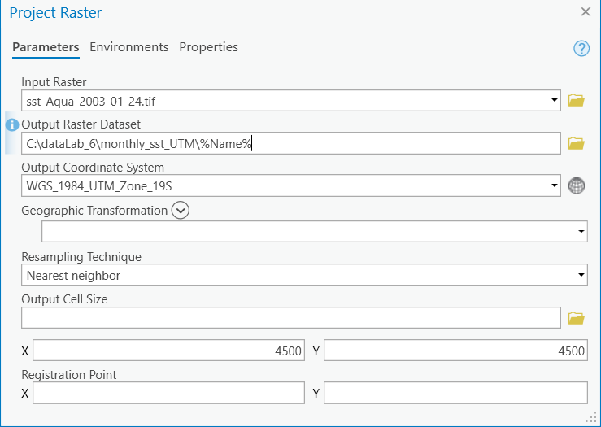

Corra su modelo y revise los resultados obtenidos.

### 1.5.- Parametrización y documentación

De momento, nuestros modelos han funcionado, pero no han sido operacionalizados como herramientas. Para esto, debemos parametrizar cada uno de estos modelos e indicar dentro de los mismos que elementos serán dinámicos y cuales permanentes.

Usemos nuestro primer modelo, vaya al catálogo y de click derecho **Edit** sobre el modelo.

Paro configurar una entrada, salida o valor intermedio como parámetro debemos dar click derecho sobre el mismo y seleccionar la opción **Parameter** lo que pondrá una **P** sobre ese elemento.

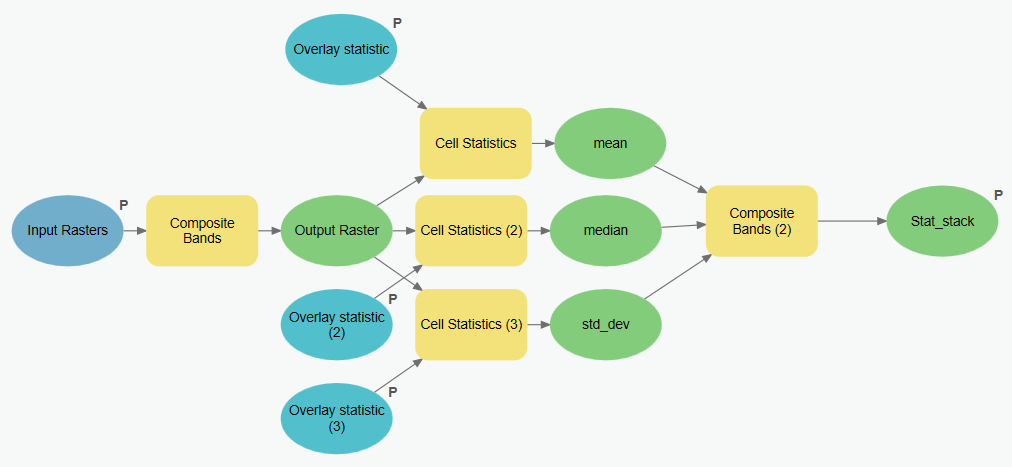

Borre las entradas originales dispuestas en el modelo y luego guarde el archivi. Oprima doble click para abrir su herramienta y vea el resultado.

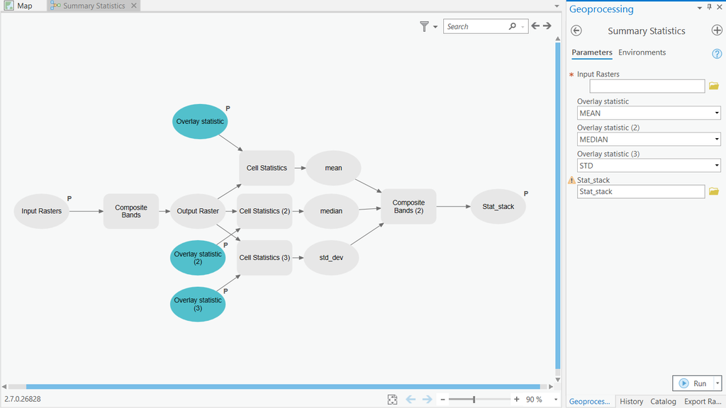

Podemos ordenar los parámetros y ver información de cada en el menú **Model/Properties**

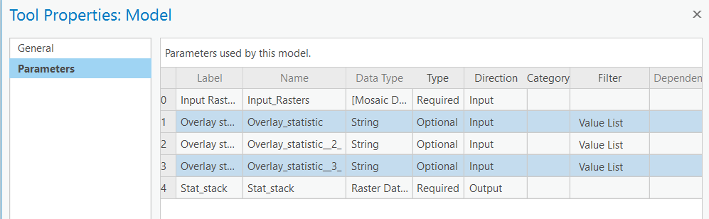

Finalmente podemos editar la documentación de nuestra herramienta, dando clic derecho **Edit Metadata**.

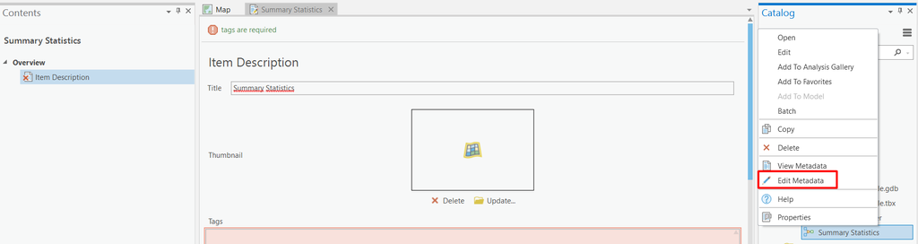

*¿Qué cambios cree que habría que hacer a la herramienta?*

## 2.- Ejercicios

2.1 Empleando la capa **Earthquake_2000-2019_35_9_Coquimbo_Biobio.shp** realizce un modelo que cumpla con las siguientes tareas:

- Reproyecte la capa a **UTM WGS84 19S**
- Calcule la banda de distancia promedio, mínima y máxima para un número de 6 puntos vecinos
- Realice un KDE considerando la banda de distancia promedio multiplicada por 10

*Incorpore un ejemplo de funcionamiento*

2.2 Agregue al modelo generado en el punto anterior variables que permitan controlar:

- Tamaño de celda de salida del KDE
- Selección de CRS
- Posibilidad de seleccionar datos en base a un campo de la tabla.

*Incorpore un par de ejemplos de funcionamiento*

2.3 Parametrice y documente su modelo, agregando una salida adicional a elección en el modelo: ej. isolineas, raster reclasificado, polígonos, etc.

Deberá entregar el proyecto de **ArcGIS Pro** con cada modelo invidualizado y los datos de entrada y salida de cada uno, además de los ejemplos correspondientes. Considere un documento **PDF** con una explicación de cada modelo